# Lecture 8 Logistics Regression and Time Series

# Time-Series Analysis in R

## Preparation

```r
library(dplyr)
library(tidyr)
# load necessary library and packages for the analysis
library(tseries)
#install.packages('forecast') # install forecast package if first time
library(forecast)
#install.packages('lmtest') # install forecast package if first time
library(lmtest)
```

```r
#install.packages('TTR') # install forecast package if first time
library(TTR)
#install.packages('ggplot2') # install forecast package if first time
# I will showcase R's data visualization capability with `ggplot2`
library(ggplot2)
library(scales)
```

Remark: We shall first look at logistic regression with an example of `titanic`.  
Then we’’ play with time-series data with a series of examples.

## Main Analysis A - Logistic Regression

### Data Cleaning

```r
# we shall use another dataset about survival of passengers on the Titanic.
# 'train.csv' is the raw data and 'titanic.csv' is the one after basic cleaning done below.
# for logistic analysis, use 'titanic.csv' directly. Data cleaning process is for your reference.
# read CSV file into data frame and use 'na.string' to make sure that missing value is coded as 'NA'.
titanic_raw = read.csv('train.csv', header = TRUE, na.string = c(""))
# change variable names to lower cases.
names(titanic_raw) = tolower(names(titanic_raw))
# for illustration purpose, I keep the obs with missing values in 'Age' and replace missing values with median of non-missing ones.
# WARNINGS: this should not be the practice in real world application. Otherwise, data contamination or plagiarism.
titanic_raw$age[is.na(titanic_raw$age)] = median(titanic_raw$age,na.rm=TRUE)
# export the data set after cleaning as CSV file.
write.csv(titanic_raw, "/Users/haowei/NUS/BT1101/Week 8/titanic.csv", row.names = FALSE)

# QN: does ~ mean current directory?
```

### Data Input

```r
# read 'titanic.csv' file into data frame object 'titanic'.
titanic = read.csv('titanic.csv', header = TRUE)
# use 'glm()' with specified parameter 'family = binomial' for logistic regression.
fit_surv = glm(survived ~ sex + age + sibsp + parch + fare + embarked, family = binomial, data = titanic, control = list(maxit = 50))
# display the output of logistic regression
summary(fit_surv)
```

```
##
## Call:
## glm(formula = survived ~ sex + age + sibsp + parch + fare + embarked,
##     family = binomial, data = titanic, control = list(maxit = 50))
##
## Deviance Residuals:
##     Min       1Q   Median       3Q      Max
## -2.4061  -0.6454  -0.5270   0.7382   2.3798
##
## Coefficients:
##              Estimate Std. Error z value Pr(>|z|)
## (Intercept)  1.991142   0.335272   5.939 2.87e-09 ***
## sexmale     -2.635345   0.190231 -13.853  < 2e-16 ***
## age         -0.020467   0.007201  -2.842 0.004482 **
## sibsp       -0.394275   0.103822  -3.798 0.000146 ***
## parch       -0.222958   0.114051  -1.955 0.050595 .
## fare         0.014730   0.002849   5.170 2.34e-07 ***
## embarkedQ   -0.679104   0.362057  -1.876 0.060699 .
## embarkedS   -0.504620   0.226659  -2.226 0.025992 *
## ---
## Signif. codes:  0 '***' 0.001 '**' 0.01 '*' 0.05 '.' 0.1 ' ' 1
##
## (Dispersion parameter for binomial family taken to be 1)
##
##     Null deviance: 1182.82  on 888  degrees of freedom
## Residual deviance:  844.15  on 881  degrees of freedom
##   (2 observations deleted due to missingness)
## AIC: 860.15
##
## Number of Fisher Scoring iterations: 5
```

```r
# Compute the odds ratio and CI's for each coefficient.
exp(cbind(OddsRatio = coef(fit_surv), confint(fit_surv)))
```

```
##              OddsRatio      2.5 %     97.5 %
## (Intercept) 7.32389012 3.84008259 14.3194752
## sexmale     0.07169421 0.04899344  0.1033607
## age         0.97974147 0.96580199  0.9934871
## sibsp       0.67416892 0.54377479  0.8180237
## parch       0.80014881 0.63689642  0.9994883
## fare        1.01483917 1.00946753  1.0208302
## embarkedQ   0.50707121 0.24771886  1.0259723
## embarkedS   0.60373494 0.38750889  0.9433470
```

Remarks: ‘control = list(maxit = 50)’ is used to increase maximum number of iteration of computation in glm as to make sure algorithm converges. Watch out for interpretation of coefficient of logistics regression. Original coeff gives the log-OddsRatio, exp(coeff) then gives you the odds ratio. Interpretation of b: Every one unit increase of X results in the log-odds of Pr(Y=1) increase/decrease by b, or equivalently, odds of Pr(Y=1) mutiplied by exp(b). A good reference for logistics regression in R: https://web.archive.org/web/20110319043907/http://www.ats.ucla.edu/stat/r/dae/logit.htm.

## Main Analysis B: Linear Regression with Time-Series Data

Produce seasonal pattern in time series using souvenir shop at a beach resort town in Queensland, Australia http://robjhyndman.com/tsdldata/data/fancy.dat contains monthly sales for a souvenir shop at a beach resort town in Queensland, Australia, for January 1987-December 1993 (original data from Wheelwright and Hyndman, 1998).

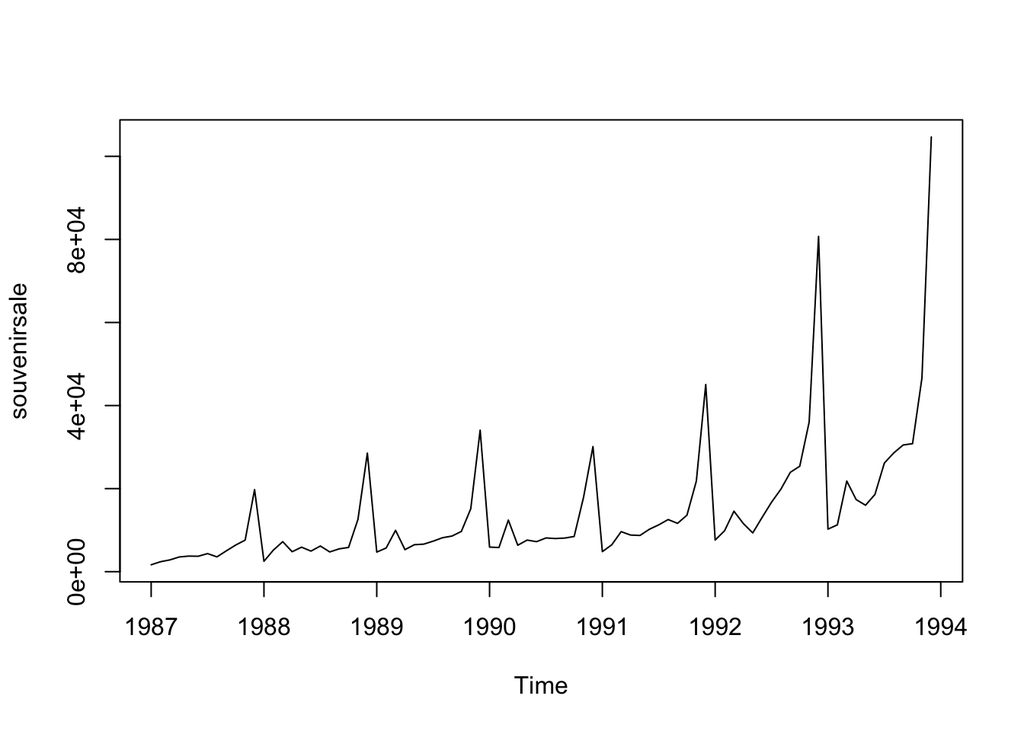

```r
souvenir = scan("http://robjhyndman.com/tsdldata/data/fancy.dat")
souvenirsale = ts(souvenir, frequency=12, start=c(1987,1))
write.csv(souvenirsale, "/Users/haowei/NUS/BT1101/Week 8/timesR", row.names = FALSE) # check what's timesR

log_souvenirsale = log(souvenirsale)
plot.ts(souvenirsale)
```

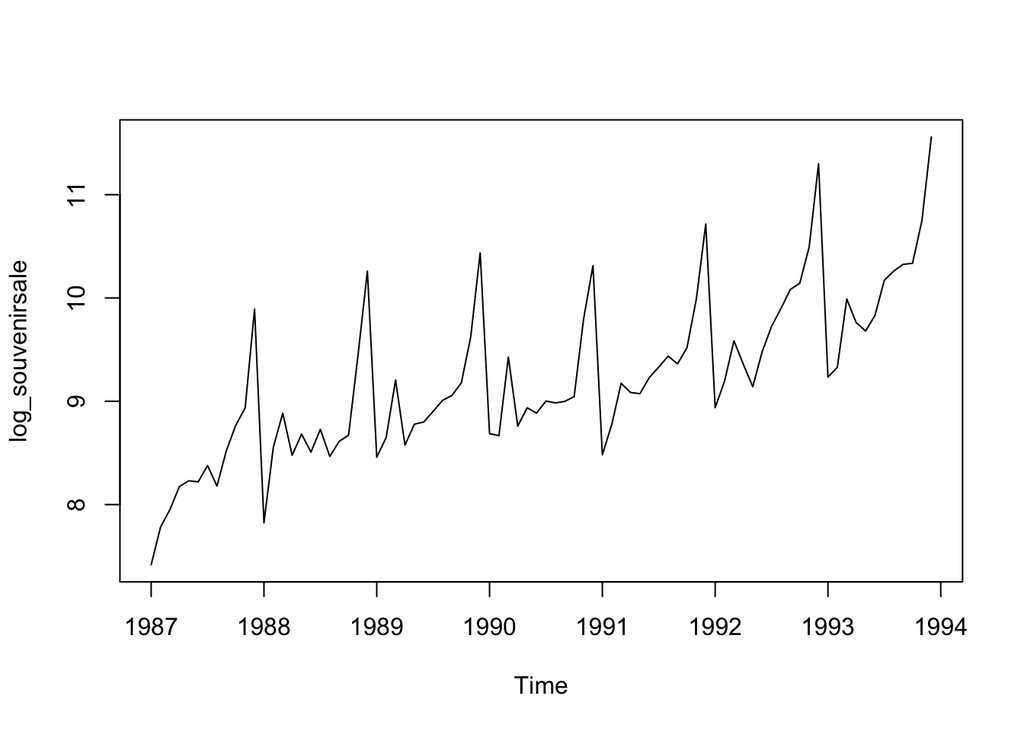

```r
plot.ts(log_souvenirsale)
```

Load `hseinv` data set from wooldrige (https://cran.r-project.org/web/packages/wooldridge/index.html). There are two ways that you can load the data set. You can use read.csv() function to read ‘hseinv.csv’ file directly if you put the CSV file into your working directory. Here we shall use the second way to load, especially public avaiable data set in to R workspace. Many public available data sets are already packaged, e.g. library(wooldridge). Install the package ‘wooldridge’ first and load the package.

```r
# install.packages('wooldridge') # install the package if first time
library(wooldridge)
# cross-sectional vs. time series. vs panel
data('mroz'); data(hseinv); data('jtrain')
# load the data set as dataframe named 'hseinv'
data('hseinv')
# use 'ts()' to convert a normal dataframe object into time series object with specification of frequency (monthly, =12; quarterly, =4; or yearly, =1)
hseinvts = ts(hseinv, start = c(1947), end = c(1988), frequency = 1)
```

### OLS Regression for Time Series

As an example of “spurious regression”, run OLS regression of housing investment per capita on housing price index Since you still use OLS regression here, specific to time series objects, there is no difference using data.frame or converted ts objective.

```r
fit_ip = lm(invpc ~ price, data = hseinv)
summary(fit_ip)
```

```
##
## Call:
## lm(formula = invpc ~ price, data = hseinv)
##
## Residuals:
##      Min       1Q   Median       3Q      Max
## -0.22015 -0.04771 -0.01224  0.04334  0.20030
##
## Coefficients:
##             Estimate Std. Error t value Pr(>|t|)
## (Intercept)  -0.1366     0.2010   -0.68  0.50064
## price         0.7209     0.2198    3.28  0.00215 **
## ---
## Signif. codes:  0 '***' 0.001 '**' 0.01 '*' 0.05 '.' 0.1 ' ' 1
##
## Residual standard error: 0.0833 on 40 degrees of freedom
## Multiple R-squared:  0.212,  Adjusted R-squared:  0.1923
## F-statistic: 10.76 on 1 and 40 DF,  p-value: 0.002153
```

```r
# fit OLS regression with additional time trend variable 't'.
fit_ipt = lm(invpc ~ price + t, data = hseinv)
summary(fit_ipt)
```

```
##
## Call:
## lm(formula = invpc ~ price + t, data = hseinv)
##
## Residuals:
##       Min        1Q    Median        3Q       Max
## -0.215651 -0.045053 -0.006395  0.045029  0.152302
##
## Coefficients:
##              Estimate Std. Error t value Pr(>|t|)
## (Intercept)  0.609042   0.313477   1.943   0.0593 .
## price       -0.222725   0.378973  -0.588   0.5601
## t            0.005375   0.001829   2.939   0.0055 **
## ---
## Signif. codes:  0 '***' 0.001 '**' 0.01 '*' 0.05 '.' 0.1 ' ' 1
##
## Residual standard error: 0.07633 on 39 degrees of freedom
## Multiple R-squared:  0.3549, Adjusted R-squared:  0.3218
## F-statistic: 10.73 on 2 and 39 DF,  p-value: 0.000194
```

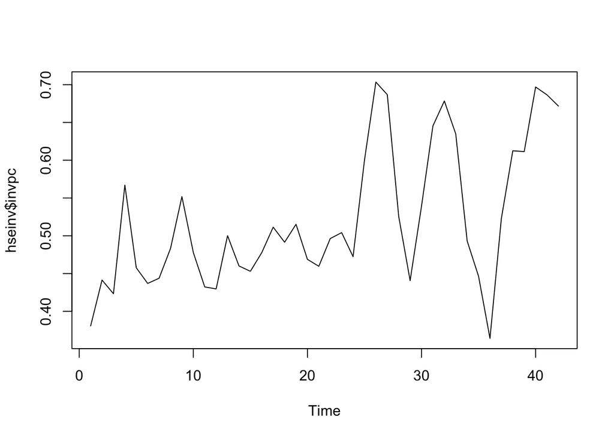

```r
ts.plot(hseinv$invpc)
```

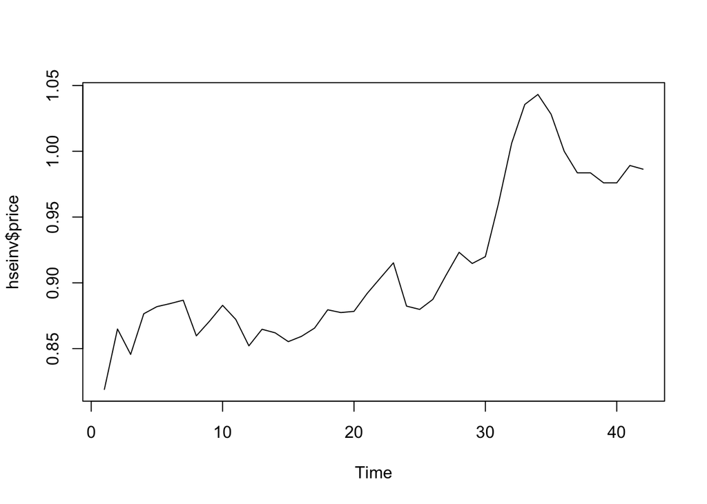

```r
ts.plot(hseinv$price)
```

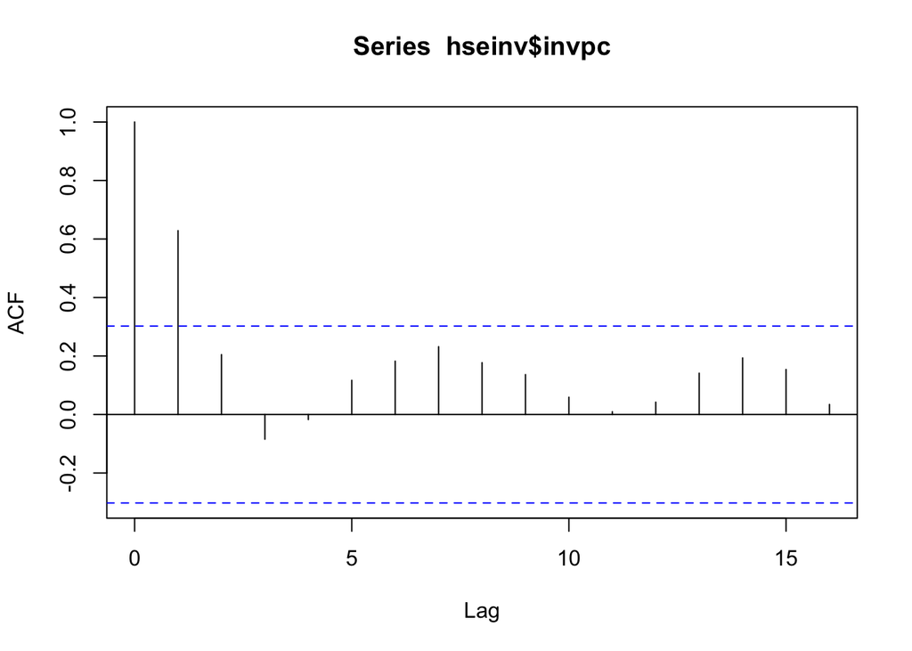

```r
acf(hseinv$invpc)
```

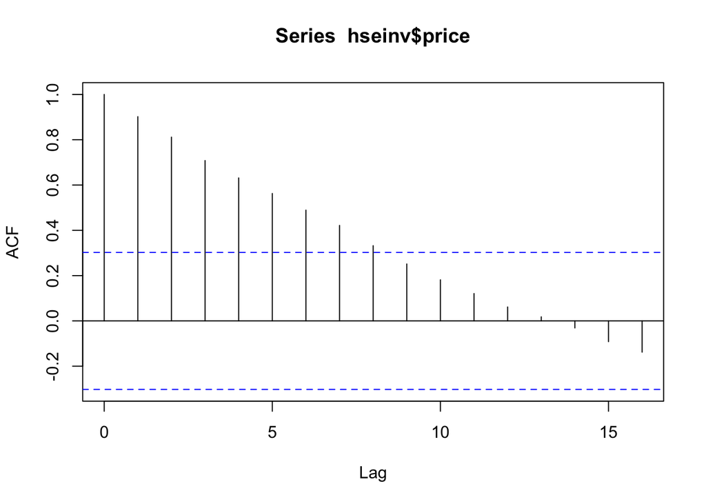

```r
acf(hseinv$price)
```

## Main Analysis C: Smoothing Models for Univariate Time Series

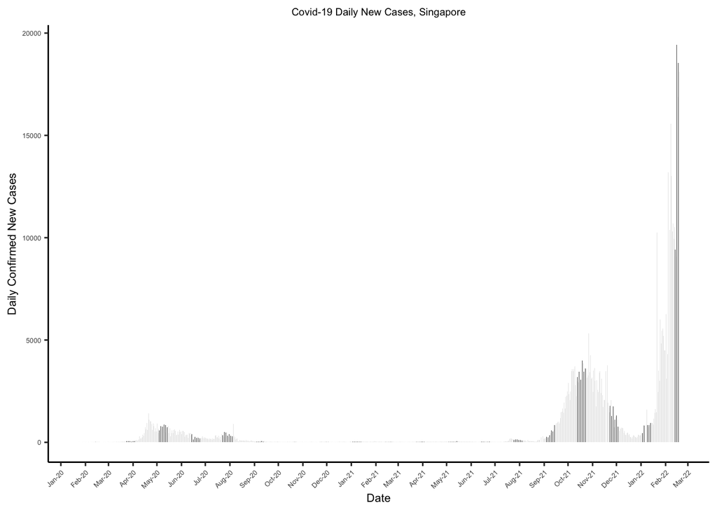

```r
# import and prepare data set
# The data set is public data on daily covid cases from "Our World Data" (Github: https://github.com/owid/covid-19-data/tree/master/public/data)
raw = read.csv(file = 'owid-covid-data.csv', header = TRUE)
# I'd like to define a `Date` variable as date format with `as.Date()`
raw$Date = as.Date(raw$date)

# Subsetting two time series data on Singapore and World
covid_sg = raw %>% subset(location == 'Singapore', select = c(location, Date, new_cases, new_tests, new_deaths, icu_patients, new_vaccinations))

covid_w = raw %>% subset(location == 'World', select = c(location, Date, new_cases, new_tests, new_deaths, icu_patients, new_vaccinations))

## visualize the original time series using `ggplot2`
ggplot(covid_sg, aes(x=Date, y=new_cases)) + geom_bar(stat="identity", width=0.1) +
  theme_classic() +
  labs(title = "Covid-19 Daily New Cases, Singapore", x= "Date", y= "Daily Confirmed New Cases") +
  theme(plot.title = element_text(hjust = 0.5)) +
  scale_x_date(date_breaks = "months" , date_labels = "%b-%y") +  #library(scales) used for easy date format
  theme(axis.text.x = element_text(angle = 45, hjust = 1), text = element_text(size = 6), axis.title =element_text(size = 8))
```

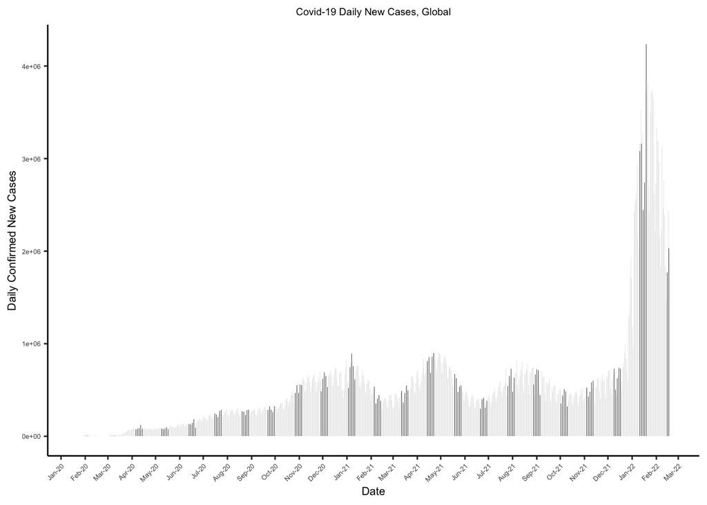

```r
ggplot(covid_w, aes(x=Date, y=new_cases)) + geom_bar(stat="identity", width=0.1) +
  theme_classic() +
  labs(title = "Covid-19 Daily New Cases, Global", x= "Date", y= "Daily Confirmed New Cases") +
  theme(plot.title = element_text(hjust = 0.5)) +
  scale_x_date(date_breaks = "months" , date_labels = "%b-%y") +  #library(scales) used for easy date format
  theme(axis.text.x = element_text(angle = 45, hjust = 1), text = element_text(size = 6), axis.title =element_text(size = 8))
```

```r
# I could also save the plot as a high quality PDF (since it is vectorized)
pdf("covid-new-sg.pdf", width=5, height=3)
mar <- par("mar")
mar = c(4,4,2,0.5)
par(mar = mar)
ggplot(covid_sg, aes(x=Date, y=new_cases)) + geom_bar(stat="identity", width=0.1) +
  theme_classic() +
  labs(title = "Covid-19 Daily New Cases, Singapore", x= "Date", y= "Daily Confirmed New Cases") +
  theme(plot.title = element_text(hjust = 0.5)) +
  scale_x_date(date_breaks = "months" , date_labels = "%b-%y") +  #library(scales) used for easy date format
  theme(axis.text.x = element_text(angle = 45, hjust = 1), text = element_text(size = 6), axis.title =element_text(size = 8))
dev.off()
```

```r
pdf("covid-new-world.pdf", width=5, height=3)
mar <- par("mar")
mar = c(4,4,2,0.5)
par(mar = mar)
ggplot(covid_w, aes(x=Date, y=new_cases)) + geom_bar(stat="identity", width=0.1) +
  theme_classic() +
  labs(title = "Covid-19 Daily New Cases, Global", x= "Date", y= "Daily Confirmed New Cases") +
  theme(plot.title = element_text(hjust = 0.5)) +
  scale_x_date(date_breaks = "months" , date_labels = "%b-%y") +  #library(scales) used for easy date format
  theme(axis.text.x = element_text(angle = 45, hjust = 1), text = element_text(size = 6), axis.title =element_text(size = 8))
dev.off()
```

### Moving-Average

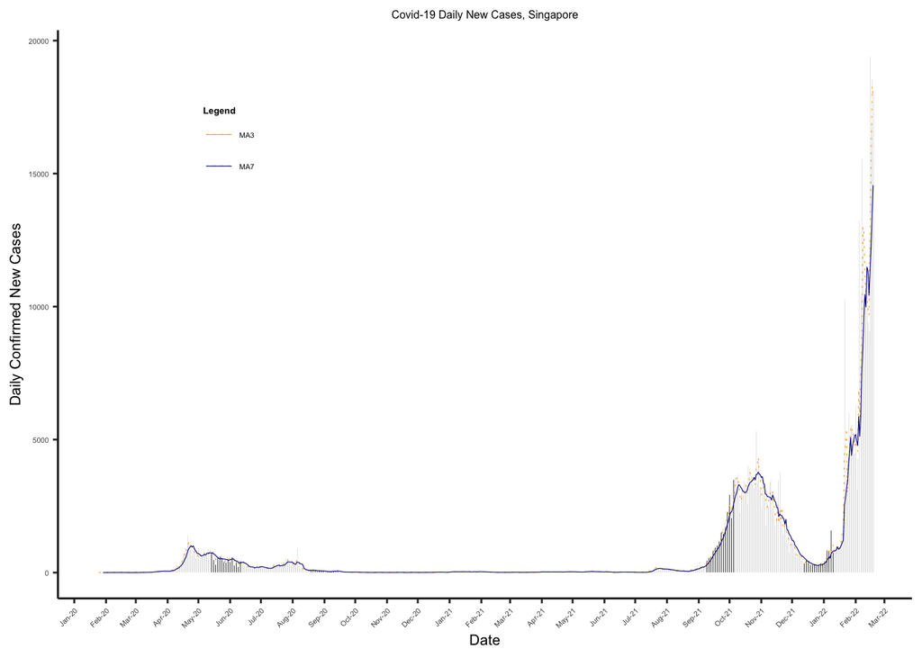

```r
## Let's first smooth the original time-series with moving averages

# Moving average (MA) with windows of 3 days for SG new cases.
# There are many alternatives, but I use `TTR::SMA()` here.
covid_sg$ma3 = SMA(covid_sg$new_cases, n = 3)
# remark: note that `ma3_sg` lost first 2 observations when computing the moving averages. For moving averages with K period window, (K-1) obs will be lost.

# Moving average (MA) with windows of 7 days for SG new cases.
covid_sg$ma7 = SMA(covid_sg$new_cases, n = 7)


ggplot(covid_sg, aes(x=Date, y=new_cases)) + geom_bar(stat="identity", width=0.1) +
  geom_line(aes(y = ma3, color = "MA3"), linetype = 3, size=0.2) +
  geom_line(aes(y = ma7, color = "MA7"), linetype = 1, size=0.2) +
  theme_classic() +
  labs(title = "Covid-19 Daily New Cases, Singapore", x= "Date", y= "Daily Confirmed New Cases") +
  theme(plot.title = element_text(hjust = 0.5)) +
  scale_x_date(date_breaks = "months" , date_labels = "%b-%y") +        #library(scales) used for easy date format
  theme(axis.text.x = element_text(angle = 45, hjust = 1), text = element_text(size = 6), axis.title =element_text(size = 8)) +
  theme(legend.title = element_text(size=5, face="bold"),  legend.direction = "vertical",
        legend.position=c(0.2, 0.8), text = element_text(size=5)) +
  scale_color_manual(name="Legend",values = c("MA3" = "orange", "MA7" = "darkblue"))
```

```r
# If we are using `ma3` as the prediction for tomorrow's value based on the moving averages, we simply "shift down" by one row.
covid_sg$pred_ma3 = lag(covid_sg$ma3, 1)

# remark: since put `ma3` value as prediction for tomorrow's, additional one row was shifted down. First 3 observations become `NA` for `covid_sg$pred_ma3`.
```

### Exponential Smoothing Models

```r
# Now let's smooth the original time-series with exponential smoothing models, i.e. simple exponential, double exponential, and Holt-Winter models. We shall use `HoltWinters()` to do the computations.
# `HoltWinters` only takes `ts`, a time-series object, rather than dataframe. Let's first convert our dataframe variable into single `ts` object.
count_day = seq(as.Date("2020-01-23"), as.Date("2022-02-18"), by = "day")
# make sure I specified the starting day correctly
new_cases_sg = ts(covid_sg$new_cases, frequency = 365, start = c(2020, as.numeric(format(count_day[1], "%j"))))
str(new_cases_sg)
```

```
##  Time-Series [1:758] from 2020 to 2022: 1 2 0 1 1 2 0 3 3 3 ...
```

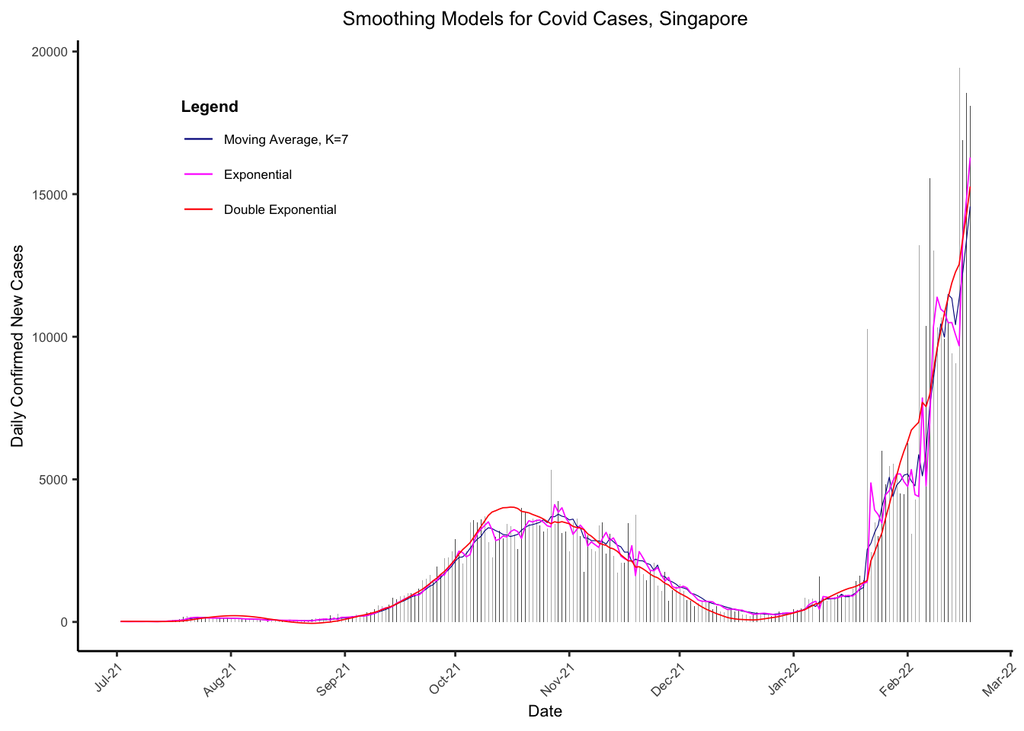

```r
# simple exponential smoothing
new_cases_exp = HoltWinters(new_cases_sg, beta = FALSE, gamma = FALSE)
# prediction
new_cases_exp_pred = predict(new_cases_exp, n.ahead = 21)

# double exponential smoothing, trend-accounted,
new_cases_double_exp = HoltWinters(new_cases_sg, gamma = FALSE)

# Remark: given the this current covid-sg data, HoltWinters' optimization process failed to converge. An alternative is to use `forecast::ets()`.
# For additive double exponential smoothing, call `ets(, model = "AAN")`.
new_cases_double_exp_ets = ets(new_cases_sg, model = "AAN")

# prediction
new_cases_double_exp_pred = predict(new_cases_double_exp_ets, n.ahead = 21)

df_exps = ts.union(new_cases_sg, new_cases_exp$fitted[,"xhat"], new_cases_double_exp_ets$fitted, dframe=TRUE)
df_exps = cbind(df_exps, covid_sg$Date, covid_sg$ma7)
colnames(df_exps) = c("new_cases", "exp", "double_exp","Date","ma7")

# plot the filtered (or smoothed) series with exponential weights

ggplot(df_exps[which(df_exps$Date>"2021-07-01"),], aes(x=Date, y=new_cases)) + geom_bar(stat="identity", width=0.1) +
  geom_line(aes(y = ma7, color = "Moving Average, K=7"), linetype = 1, size=0.2) +
  geom_line(aes(y = exp, color = "Exponential"), linetype = 1, size=0.3) +
  geom_line(aes(y = double_exp, color = "Double Exponential"), linetype = 1, size=0.3) +
  theme_classic() +
  labs(title = "Smoothing Models for Covid Cases, Singapore", x= "Date", y= "Daily Confirmed New Cases") +
  theme(plot.title = element_text(hjust = 0.5)) +
  scale_x_date(date_breaks = "months" , date_labels = "%b-%y") +        #library(scales) used for easy date format
  theme(axis.text.x = element_text(angle = 45, hjust = 1), text = element_text(size = 8), axis.title =element_text(size = 8)) +
  theme(legend.title = element_text(size=8, face="bold"),  legend.direction = "vertical",
        legend.position=c(0.2, 0.8), text = element_text(size=8)) +
  scale_color_manual(name="Legend",values = c("Moving Average, K=7" = "darkblue", "Exponential" = "magenta", "Double Exponential" = "red"))
```

```r
# Remarks: HoltWinters in R uses `decompose()` function to get the initial parameter value to kick start an iteration of optimization to get the estimates for alpha, beta and gamma.
# `decompose()` requires the number of observations is at least as twice large as the frequency. We define the frequency with `ts` object, e.g., `f=365` for covid example.
# Note that it is subject to our decision if the original time-series exhibits seasonality.
```

## Some other examples:

```r
# using R built-in data `AirPassengers`, a predefined ts object already.
data(AirPassengers)
ap_hw = HoltWinters(AirPassengers)
print(ap_hw)
```

```
## Holt-Winters exponential smoothing with trend and additive seasonal component.
##
## Call:
## HoltWinters(x = AirPassengers)
##
## Smoothing parameters:
##  alpha: 0.2479595
##  beta : 0.03453373
##  gamma: 1
##
## Coefficients:
##           [,1]
## a   477.827781
## b     3.127627
## s1  -27.457685
## s2  -54.692464
## s3  -20.174608
## s4   12.919120
## s5   18.873607
## s6   75.294426
## s7  152.888368
## s8  134.613464
## s9   33.778349
## s10 -18.379060
## s11 -87.772408
## s12 -45.827781
```

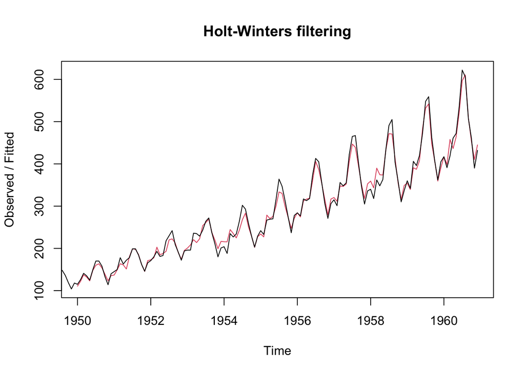

```r
# you could directly plot the original vs. fitted
plot(ap_hw)
```

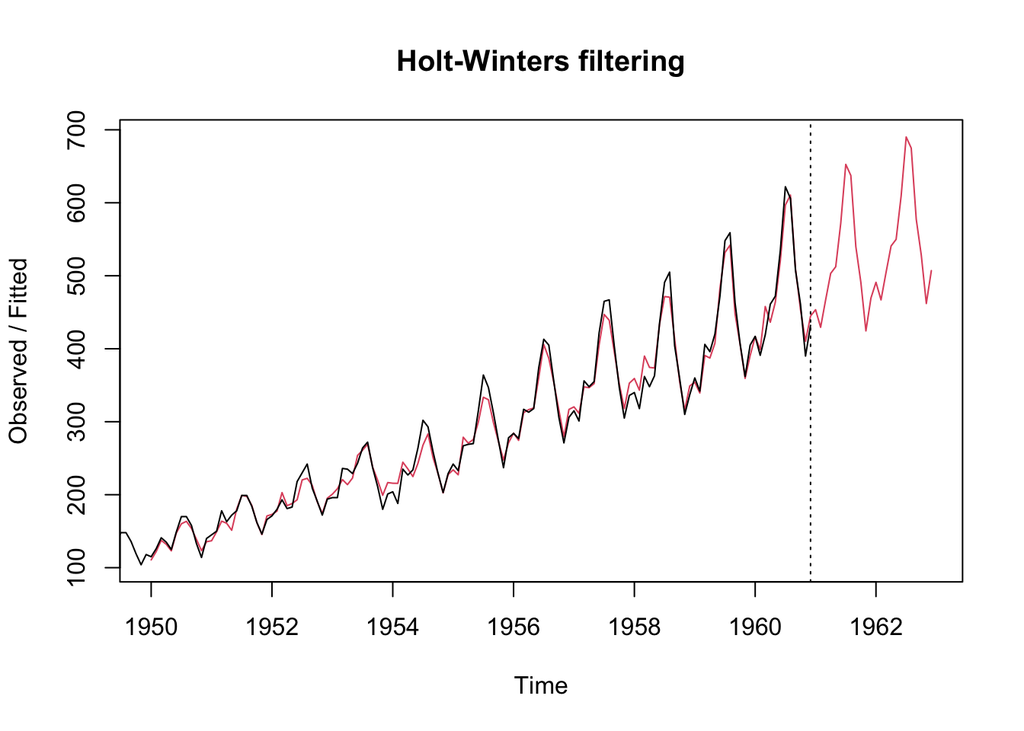

```r
# `predict()` function can also be directly applied to the fitted model for prediction.
ap_pred = predict(ap_hw, n.ahead = 24)
plot(ap_hw, ap_pred)
```

```r
# using the `souvenir` dataset before. Recall we have defined its `ts` version as `souvenirsale`.
str(souvenirsale)
```

```
##  Time-Series [1:84] from 1987 to 1994: 1665 2398 2841 3547 3753 ...
```

```r
souvenir_hw = HoltWinters(souvenirsale)
print(souvenir_hw)
```

```
## Holt-Winters exponential smoothing with trend and additive seasonal component.
##
## Call:
## HoltWinters(x = souvenirsale)
##
## Smoothing parameters:
##  alpha: 0.021882
##  beta : 1
##  gamma: 1
##
## Coefficients:
##            [,1]
## a    31552.6045
## b      778.6445
## s1  -12994.3112
## s2  -13070.8952
## s3   -3550.8387
## s4   -8961.9894
## s5  -11179.7153
## s6   -9320.5816
## s7   -2480.7650
## s8    -712.8248
## s9     639.4040
## s10    505.2548
## s11  15860.4200
## s12  73108.0655
```

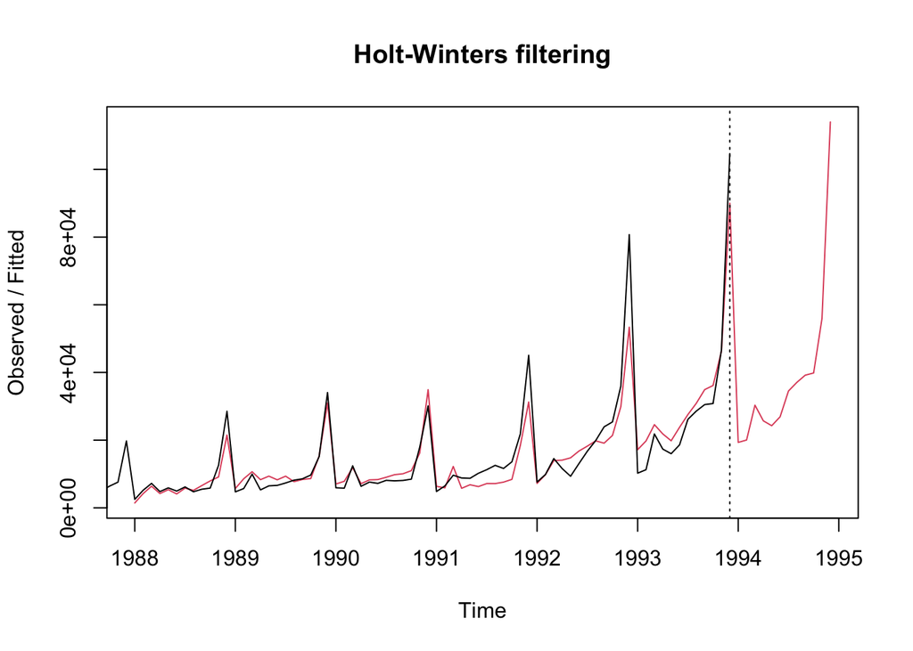

```r
souvenir_pred = predict(souvenir_hw, n.ahead = 12)
plot(souvenir_hw, souvenir_pred)
```